# Bank Churn Prediction Project - Warren V. Camp

# Objective:

Given a Bank customer, build a neural network based classifier that can determine whether they will leave or not in the next 6 months.

# Context:

Businesses like banks which provide service have to worry about problem of 'Churn' i.e. customers leaving and joining another service provider. It is important to understand which aspects of the service influence a customer's decision in this regard. Management can concentrate efforts on improvement of service, keeping in mind these priorities.

### Data Description:

The case study is from an open-source dataset from Kaggle.The dataset contains 10,000 sample points with 14 distinct features such as CustomerId,CreditScore, Geography, Gender, Age, Tenure, Balance etc.

# Points Distribution:

1. Read the dataset
2. Drop the columns which are unique for all users like IDs (5 points)
3. Distinguish the featuresand target variable(5 points)
4. Divide the data set into training and test sets (5 points)
5. Normalize the train and test data (10 points)
6. Initialize & build the model. Identify the points of improvement and implement the same.(20 points)
7. Predict the results using 0.5 as a threshold (10 points)
8. Print the Accuracy score and confusion matrix (5 points)

### 1. Read the dataset

```python
# Import all the necessary modules
import pandas as pd
import numpy as np
import seaborn as sns
import matplotlib.pyplot as plt
from sklearn import preprocessing
from sklearn.preprocessing import Normalizer, MinMaxScaler, StandardScaler
from sklearn.model_selection import train_test_split
from sklearn.metrics import confusion_matrix, classification_report, accuracy_score, mean_squared_error
from sklearn.ensemble import GradientBoostingRegressor
import tensorflow as tf
from tensorflow import keras
from tensorflow.keras.models import Sequential
from tensorflow.keras.layers import Dense, InputLayer, LeakyReLU, ReLU
from imblearn.over_sampling import SMOTE
from collections import Counter
%matplotlib inline
```

```python
print(tf.__version__)
```

```
2.1.0
```

```python
df = pd.DataFrame((pd.read_csv('bank.csv')))
```

```python
df.head()
```

|  | RowNumber | CustomerId | Surname | CreditScore | Geography | Gender | Age | Tenure | Balance | NumOfProducts | HasCrCard | IsActiveMember | EstimatedSalary | Exited |
| --- | --- | --- | --- | --- | --- | --- | --- | --- | --- | --- | --- | --- | --- | --- |
| 0 | 1 | 15634602 | Hargrave | 619 | France | Female | 42 | 2 | 0.00 | 1 | 1 | 1 | 101348.88 | 1 |
| 1 | 2 | 15647311 | Hill | 608 | Spain | Female | 41 | 1 | 83807.86 | 1 | 0 | 1 | 112542.58 | 0 |
| 2 | 3 | 15619304 | Onio | 502 | France | Female | 42 | 8 | 159660.80 | 3 | 1 | 0 | 113931.57 | 1 |
| 3 | 4 | 15701354 | Boni | 699 | France | Female | 39 | 1 | 0.00 | 2 | 0 | 0 | 93826.63 | 0 |
| 4 | 5 | 15737888 | Mitchell | 850 | Spain | Female | 43 | 2 | 125510.82 | 1 | 1 | 1 | 79084.10 | 0 |

```python
# Check for missing values
df.isnull().sum()
```

```
RowNumber          0
CustomerId         0
Surname            0
CreditScore        0
Geography          0
Gender             0
Age                0
Tenure             0
Balance            0
NumOfProducts      0
HasCrCard          0
IsActiveMember     0
EstimatedSalary    0
Exited             0
dtype: int64
```

### Comment: There are no missing values

```python
df.nunique()
```

```
RowNumber          10000
CustomerId         10000
Surname             2932
CreditScore          460
Geography              3
Gender                 2
Age                   70
Tenure                11
Balance             6382
NumOfProducts          4
HasCrCard              2
IsActiveMember         2
EstimatedSalary     9999
Exited                 2
dtype: int64
```

### Comment: There are 4 category features: Geography, Gender, HasCrCard, and IsActiveMember, There types should be addressed.

```python
# Change Gender type object to category
df['Gender'].astype('category')
```

```
0       Female
1       Female
2       Female
3       Female
4       Female
         ...
9995      Male
9996      Male
9997    Female
9998      Male
9999    Female
Name: Gender, Length: 10000, dtype: category
Categories (2, object): ['Female', 'Male']
```

```python
# Change Geography from object to category
df['Geography'].astype('category')
```

```
0        France
1         Spain
2        France
3        France
4         Spain
         ...
9995     France
9996     France
9997     France
9998    Germany
9999     France
Name: Geography, Length: 10000, dtype: category
Categories (3, object): ['France', 'Germany', 'Spain']
```

```python
# Change features from object to category
df['IsActiveMember'].astype('category')
df['HasCrCard'].astype('category')
```

```
0       1
1       0
2       1
3       0
4       1
       ..
9995    1
9996    1
9997    0
9998    1
9999    1
Name: HasCrCard, Length: 10000, dtype: category
Categories (2, int64): [0, 1]
```

### Drop the columns which are unique for all users like IDs (5 points)

RowNumber, CustomerId, and Surname

```python
df.drop(columns=['RowNumber', 'CustomerId', 'Surname'], axis=1, inplace=True)
df.head()
```

|  | CreditScore | Geography | Gender | Age | Tenure | Balance | NumOfProducts | HasCrCard | IsActiveMember | EstimatedSalary | Exited |
| --- | --- | --- | --- | --- | --- | --- | --- | --- | --- | --- | --- |
| 0 | 619 | France | Female | 42 | 2 | 0.00 | 1 | 1 | 1 | 101348.88 | 1 |
| 1 | 608 | Spain | Female | 41 | 1 | 83807.86 | 1 | 0 | 1 | 112542.58 | 0 |
| 2 | 502 | France | Female | 42 | 8 | 159660.80 | 3 | 1 | 0 | 113931.57 | 1 |
| 3 | 699 | France | Female | 39 | 1 | 0.00 | 2 | 0 | 0 | 93826.63 | 0 |
| 4 | 850 | Spain | Female | 43 | 2 | 125510.82 | 1 | 1 | 1 | 79084.10 | 0 |

### 3. Distinguish the features and target variable (5 points)

```python
# Distinguished features are: CreditScore, Geography, Gender, Age, Tenure, Balance,
#     NumOfProducts, HasCrCard, IsActiveMember, EstimatedSalary.
df.iloc[:,:10].head()
```

|  | CreditScore | Geography | Gender | Age | Tenure | Balance | NumOfProducts | HasCrCard | IsActiveMember | EstimatedSalary |
| --- | --- | --- | --- | --- | --- | --- | --- | --- | --- | --- |
| 0 | 619 | France | Female | 42 | 2 | 0.00 | 1 | 1 | 1 | 101348.88 |
| 1 | 608 | Spain | Female | 41 | 1 | 83807.86 | 1 | 0 | 1 | 112542.58 |
| 2 | 502 | France | Female | 42 | 8 | 159660.80 | 3 | 1 | 0 | 113931.57 |
| 3 | 699 | France | Female | 39 | 1 | 0.00 | 2 | 0 | 0 | 93826.63 |
| 4 | 850 | Spain | Female | 43 | 2 | 125510.82 | 1 | 1 | 1 | 79084.10 |

```python
# target variable is: Exited
print('Exited \n', df['Exited'].head())
print(df['Exited'].value_counts())
```

```
Exited
 0    1
1    0
2    1
3    0
4    0
Name: Exited, dtype: int64
0    7963
1    2037
Name: Exited, dtype: int64
```

### Comment: Imbalance on the dependent variable (Exited), approximate 80% no churn and and 20% churn

```python
df.info()
```

```
<class 'pandas.core.frame.DataFrame'>
RangeIndex: 10000 entries, 0 to 9999
Data columns (total 11 columns):
 #   Column           Non-Null Count  Dtype
---  ------           --------------  -----
 0   CreditScore      10000 non-null  int64
 1   Geography        10000 non-null  object
 2   Gender           10000 non-null  object
 3   Age              10000 non-null  int64
 4   Tenure           10000 non-null  int64
 5   Balance          10000 non-null  float64
 6   NumOfProducts    10000 non-null  int64
 7   HasCrCard        10000 non-null  int64
 8   IsActiveMember   10000 non-null  int64
 9   EstimatedSalary  10000 non-null  float64
 10  Exited           10000 non-null  int64
dtypes: float64(2), int64(7), object(2)
memory usage: 859.5+ KB
```

### Comment: There does not appear to be any null data in the dataset, evderything appears normal

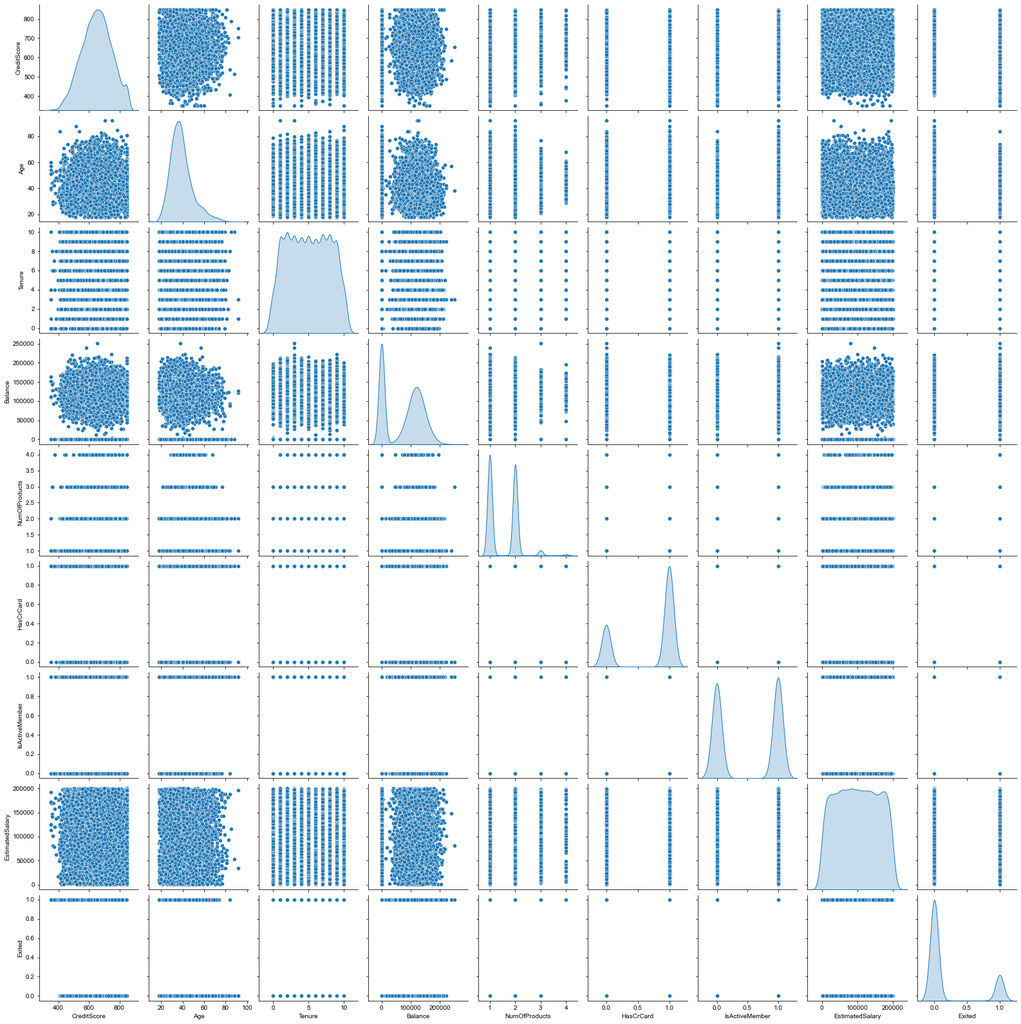

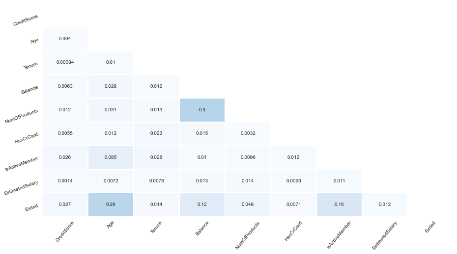

```python
sns.pairplot(df, diag_kind = 'kde')
np.tril(df.corr(), k = -1)
corr = abs(df.corr()) # correlation matrix
lower_triangle = np.tril(corr, k = -1)  # select only the lower triangle of the correlation matrix
mask = lower_triangle == 0  # to mask the upper triangle in the following heatmap

plt.figure(figsize = (15,8))  # setting the figure size
sns.set_style(style = 'white')  # Setting it to white so that we do not see the grid lines
sns.heatmap(lower_triangle, center=0.5, cmap= 'Blues', annot= True, xticklabels = corr.index, yticklabels = corr.columns,
            cbar= False, linewidths= 1, mask = mask)   # Da Heatmap
plt.xticks(rotation = 50)   # Aesthetic purposes
plt.yticks(rotation = 20)   # Aesthetic purposes
plt.show()
```

### Comment: The features appear to be independent, no coorelations close to 1.

Coorelation exists for Exited and Age (.29), Exited and Balance (.12) and Exited and IsActiveMember(.16) Very little relationship between Exited and Tenure, NumOfProducts, and HasCrCard.

```python
df.describe()
```

|  | CreditScore | Age | Tenure | Balance | NumOfProducts | HasCrCard | IsActiveMember | EstimatedSalary | Exited |
| --- | --- | --- | --- | --- | --- | --- | --- | --- | --- |
| count | 10000.000000 | 10000.000000 | 10000.000000 | 10000.000000 | 10000.000000 | 10000.00000 | 10000.000000 | 10000.000000 | 10000.000000 |
| mean | 650.528800 | 38.921800 | 5.012800 | 76485.889288 | 1.530200 | 0.70550 | 0.515100 | 100090.239881 | 0.203700 |
| std | 96.653299 | 10.487806 | 2.892174 | 62397.405202 | 0.581654 | 0.45584 | 0.499797 | 57510.492818 | 0.402769 |
| min | 350.000000 | 18.000000 | 0.000000 | 0.000000 | 1.000000 | 0.00000 | 0.000000 | 11.580000 | 0.000000 |
| 25% | 584.000000 | 32.000000 | 3.000000 | 0.000000 | 1.000000 | 0.00000 | 0.000000 | 51002.110000 | 0.000000 |
| 50% | 652.000000 | 37.000000 | 5.000000 | 97198.540000 | 1.000000 | 1.00000 | 1.000000 | 100193.915000 | 0.000000 |
| 75% | 718.000000 | 44.000000 | 7.000000 | 127644.240000 | 2.000000 | 1.00000 | 1.000000 | 149388.247500 | 0.000000 |
| max | 850.000000 | 92.000000 | 10.000000 | 250898.090000 | 4.000000 | 1.00000 | 1.000000 | 199992.480000 | 1.000000 |

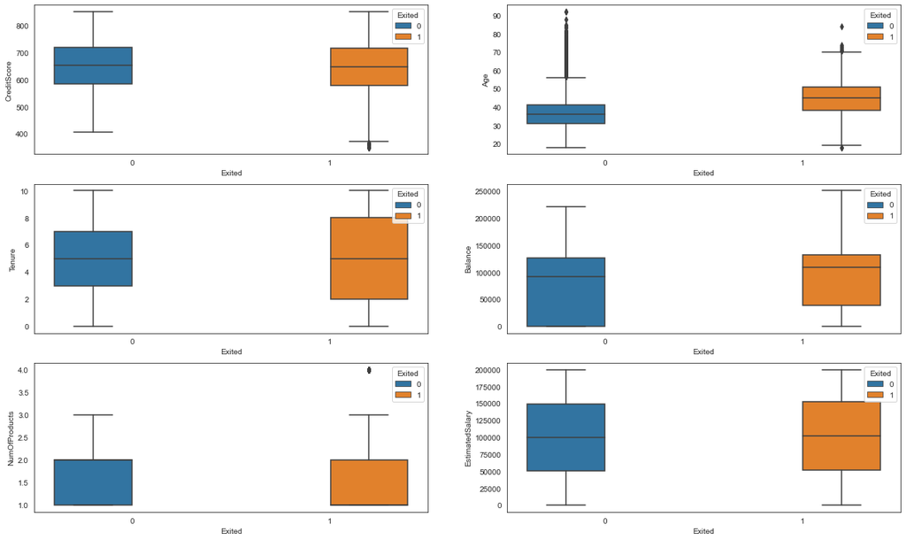

```python
# Relations based on the continuous data attributes
fig, axarr = plt.subplots(3, 2, figsize=(20, 12))
sns.boxplot(y='CreditScore',x = 'Exited', hue = 'Exited',data = df, ax=axarr[0][0])
sns.boxplot(y='Age',x = 'Exited', hue = 'Exited',data = df , ax=axarr[0][1])
sns.boxplot(y='Tenure',x = 'Exited', hue = 'Exited',data = df, ax=axarr[1][0])
sns.boxplot(y='Balance',x = 'Exited', hue = 'Exited',data = df, ax=axarr[1][1])
sns.boxplot(y='NumOfProducts',x = 'Exited', hue = 'Exited',data = df, ax=axarr[2][0])
sns.boxplot(y='EstimatedSalary',x = 'Exited', hue = 'Exited',data = df, ax=axarr[2][1])
```

```
Exited              0       1
NumOfProducts
1              3675.0  1409.0
2              4242.0   348.0
3                46.0   220.0
4                 NaN    60.0
```

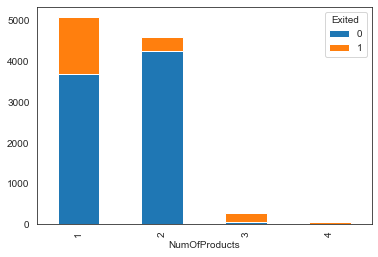

```python
nofprd_cts = df.groupby(['NumOfProducts','Exited'])['NumOfProducts'].count().unstack()
print(nofprd_cts)
nofprd_cts.plot(kind='bar', stacked=True)
```

```
Exited        0     1
HasCrCard
0          2332   613
1          5631  1424
```

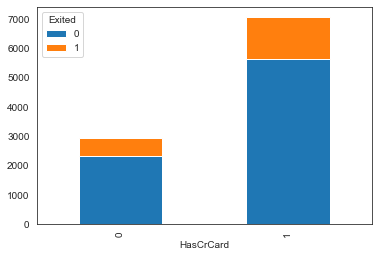

```python
crcard_cts = df.groupby(['HasCrCard','Exited'])['HasCrCard'].count().unstack()
print(crcard_cts)
crcard_cts.plot(kind='bar', stacked=True)
```

```
Exited             0     1
IsActiveMember
0               3547  1302
1               4416   735
```

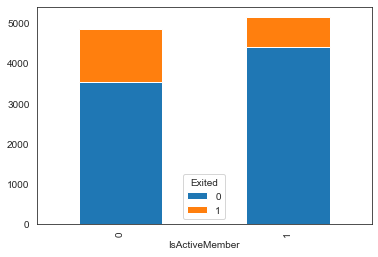

```python
actmem_cts = df.groupby(['IsActiveMember','Exited'])['IsActiveMember'].count().unstack()
print(actmem_cts)
actmem_cts.plot(kind='bar', stacked=True)
```

```python
# Segment Continuous features
segment = pd.DataFrame(columns=['EstimatedSalary', 'Age', 'CreditScore', 'Tenure', 'Balance','Exited'])
segment = segment.astype(int)
segment['Exited'] = df['Exited']
segment['Age'] = 2
segment['EstimatedSalary'] = 2
segment['Tenure'] = 2
segment['CreditScore'] = 2
segment['Balance'] = 2
segment.shape
```

```
(10000, 6)
```

```python
for i in range(len(df)):
    if df.iloc[i, 0].astype('int32') <= 584:   # CreditScore
        segment.iloc[i, 2] = 1
    if df.iloc[i, 0].astype('int32') >= 718:
        segment.iloc[i, 2] = 3
    if df.iloc[i, 3].astype('int32') <= 32:    # Age
        segment.iloc[i, 1] = 1
    if df.iloc[i, 3].astype('int32') >= 44:
        segment.iloc[i, 1] = 3
    if df.iloc[i, 4].astype('int32') <= 3:    # Tenure
        segment.iloc[i, 3] = 1
    if df.iloc[i, 4].astype('int32') >= 7:
        segment.iloc[i, 3] = 3
    if df.iloc[i, 5].astype('int32') >= 127644:  # Balance
        segment.iloc[i, 4] = 3
```

```
Exited          0    1
CreditScore
1            1978  556
2            3987  978
3            1998  503
```

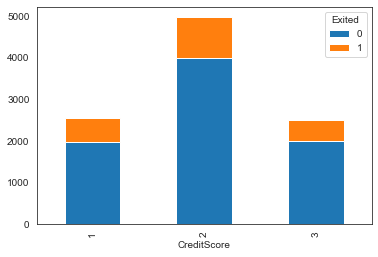

```python
counts = segment.groupby(['CreditScore', 'Exited']).CreditScore.count().unstack()
print(counts)
counts.plot(kind='bar', stacked=True)
```

```
Exited     0     1
Age
1       2577   213
2       3906   707
3       1480  1117
```

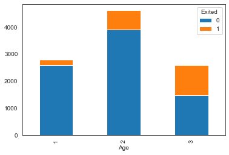

```python
counts = segment.groupby(['Age', 'Exited']).Age.count().unstack()
print(counts)
counts.plot(kind='bar', stacked=True)
```

```
Exited     0    1
Tenure
1       2764  741
2       2360  608
3       2839  688
```

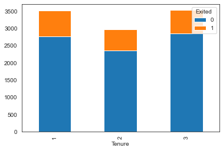

```python
counts = segment.groupby(['Tenure', 'Exited']).Tenure.count().unstack()
print(counts)
counts.plot(kind='bar', stacked=True)
```

```
Exited      0     1
Balance
2        6055  1445
3        1908   592
```

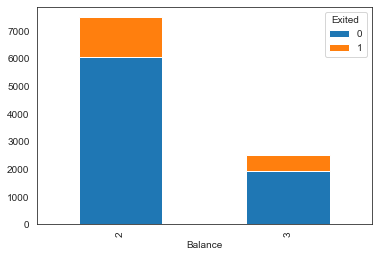

```python
counts = segment.groupby(['Balance', 'Exited']).Balance.count().unstack()
print(counts)
counts.plot(kind='bar', stacked=True)
```

```
Exited     0     1
Gender
Female  3404  1139
Male    4559   898
```

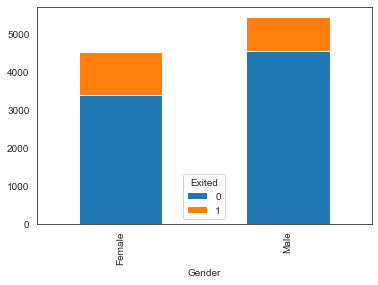

```python
counts = df.groupby(['Gender', 'Exited']).Gender.count().unstack()
print(counts)
counts.plot(kind='bar', stacked=True)
```

```python
df['Gender'].value_counts(normalize=True)
```

```
Male      0.5457
Female    0.4543
Name: Gender, dtype: float64
```

```python
# Create dummy variables for Gender - Male and Female
df = pd.get_dummies(df, columns = ['Gender'])
```

```
Exited        0    1
Geography
France     4204  810
Germany    1695  814
Spain      2064  413
```

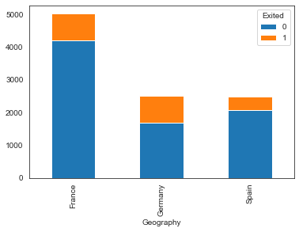

```python
geo_cts = df.groupby(['Geography','Exited'])['Geography'].count().unstack()
print(geo_cts)
geo_cts.plot(kind='bar', stacked=True)
```

```python
df['Geography'].value_counts(normalize=True)
```

```
France     0.5014
Germany    0.2509
Spain      0.2477
Name: Geography, dtype: float64
```

```python
# Create dummy variables for Gender - France, Germany and Spain
df = pd.get_dummies(df, columns = ['Geography'])
```

```python
# drop extra Gender and Geography columns that are not needed, they provide no new information
df.drop(columns=['Gender_Male', 'Geography_Spain'], axis=1, inplace=True)
```

```python
df.head()
```

|  | CreditScore | Age | Tenure | Balance | NumOfProducts | HasCrCard | IsActiveMember | EstimatedSalary | Exited | Gender_Female | Geography_France | Geography_Germany |
| --- | --- | --- | --- | --- | --- | --- | --- | --- | --- | --- | --- | --- |
| 0 | 619 | 42 | 2 | 0.00 | 1 | 1 | 1 | 101348.88 | 1 | 1 | 1 | 0 |
| 1 | 608 | 41 | 1 | 83807.86 | 1 | 0 | 1 | 112542.58 | 0 | 1 | 0 | 0 |
| 2 | 502 | 42 | 8 | 159660.80 | 3 | 1 | 0 | 113931.57 | 1 | 1 | 1 | 0 |
| 3 | 699 | 39 | 1 | 0.00 | 2 | 0 | 0 | 93826.63 | 0 | 1 | 1 | 0 |
| 4 | 850 | 43 | 2 | 125510.82 | 1 | 1 | 1 | 79084.10 | 0 | 1 | 0 | 0 |

### 4. Divide the data set into training and test sets (5 points)

```python
# Prepare the data for the training set
X = df.iloc[:,:].astype('float32')
X = X.drop(columns=['Exited'])
y = df['Exited'].astype('int32')
```

```python
X.info()
```

```
<class 'pandas.core.frame.DataFrame'>
RangeIndex: 10000 entries, 0 to 9999
Data columns (total 11 columns):
 #   Column             Non-Null Count  Dtype
---  ------             --------------  -----
 0   CreditScore        10000 non-null  float32
 1   Age                10000 non-null  float32
 2   Tenure             10000 non-null  float32
 3   Balance            10000 non-null  float32
 4   NumOfProducts      10000 non-null  float32
 5   HasCrCard          10000 non-null  float32
 6   IsActiveMember     10000 non-null  float32
 7   EstimatedSalary    10000 non-null  float32
 8   Gender_Female      10000 non-null  float32
 9   Geography_France   10000 non-null  float32
 10  Geography_Germany  10000 non-null  float32
dtypes: float32(11)
memory usage: 429.8 KB
```

```python
X.nunique()
```

```
CreditScore           460
Age                    70
Tenure                 11
Balance              6382
NumOfProducts           4
HasCrCard               2
IsActiveMember          2
EstimatedSalary      9999
Gender_Female           2
Geography_France        2
Geography_Germany       2
dtype: int64
```

```python
test_size = 0.20 # taking 80:20 training and test set
seed = 7         # Random numbmer seeding for reapeatability of the code
X_train, X_test, y_train, y_test = train_test_split(X, y, test_size=test_size, random_state=seed)
input_size = 11
```

### 5. Normalize the train and test data (10 points)

```python
# Use StandardScaler to normaize data
sc = StandardScaler()
X_train = sc.fit_transform(X_train)
X_test = sc.fit_transform(X_test)
```

### 6. Initialize & build the model. Identify the points of improvement and implement the same. (20 points)

```python
output_size = 1
validation_split = 0.2
epochs = 200
lr = 0.0001

# Initialize the constructor
model = tf.keras.models.Sequential()

# Add an input layer with 11 nodes
model.add(tf.keras.layers.Dense(units = 16,activation='relu' ,input_dim = 11, name='dense_layer_1'))

# Add hidden layer
model.add(Dense(units = 16 ,activation='relu', name='dense_layer_2'))


# Add an output layer with one node
model.add(tf.keras.layers.Dense(units = 1, activation = 'sigmoid', name='dense_layer_output'))
```

```python
OPTIMIZER = tf.keras.optimizers.Adam(learning_rate=lr)

model.compile(loss='binary_crossentropy', optimizer=OPTIMIZER , metrics = ['accuracy'])
```

```python
%%time

history = model.fit(X_train, y_train ,validation_split=validation_split, batch_size=64,epochs=epochs, verbose=0)

test_loss, test_acc = model.evaluate(X_test, y_test)
print ('Loss: ', test_loss, 'Accuracy: ', test_acc)
```

```
Loss:  0.35947989058494567 Accuracy:  0.853
Wall time: 21.4 s
```

```python
model.summary()
```

```
Model: "sequential_3"
_________________________________________________________________
Layer (type)                 Output Shape              Param #
=================================================================
dense_layer_1 (Dense)        (None, 16)                192
_________________________________________________________________
dense_layer_2 (Dense)        (None, 16)                272
_________________________________________________________________
dense_layer_output (Dense)   (None, 1)                 17
=================================================================
Total params: 481
Trainable params: 481
Non-trainable params: 0
_________________________________________________________________
```

```python
weights = model.get_weights()
print(weights)
for i in range(len(weights)):
    print(weights[i].shape)
```

```
[array([[-0.3689438 ,  0.16567284,  0.08926807,  0.1414403 ,  0.2035183 ,
         0.05426634,  0.05264218,  0.186338  , -0.09552631, -0.16973571,
         0.12003358, -0.18180121,  0.13065189, -0.06420084,  0.29778218,
         0.2979817 ],
       [-0.02019888, -0.0639713 ,  0.40273842, -0.21528924, -0.79648805,
         0.34778956, -0.56379914, -0.24862753, -0.70303845, -0.22569413,
         0.11989737,  0.56076366,  0.14107013,  0.656092  ,  0.23937742,
        -0.1535218 ],
       [ 0.21779272,  0.27580014, -0.3389371 , -0.30727223, -0.3414037 ,
        -0.0863489 , -0.30289057, -0.38485909,  0.17430589,  0.40270314,
         0.3170543 ,  0.04401483,  0.29116368,  0.30834228,  0.31902465,
         0.17207247],
       [-0.2086798 , -0.47564185,  0.35029718,  0.06107589,  0.28566656,
        -0.08098577,  0.22044024,  0.2811088 , -0.38617465,  0.30046666,
        -0.34871668,  0.22573017, -0.2258088 ,  0.41928202,  0.597432  ,
         0.47541407],
       [-0.21682255, -0.7775988 , -0.256519  , -0.21134938, -0.14006354,
        -0.86877495, -0.20765835,  0.9113072 ,  0.02690565,  0.43765554,
         0.5186465 ,  0.27927214, -0.02579278,  0.6878095 , -0.39130053,
        -0.08763745],
       [-0.4433741 , -0.11029191,  0.1163307 , -0.08059572, -0.16874239,
        -0.04523891, -0.18601654,  0.13236517,  0.53718895,  0.19004808,
        -0.30793118, -0.32512623,  0.5285084 , -0.07806308,  0.01372242,
        -0.00901175],
       [ 0.26437047,  0.02683821, -0.21835199,  0.01810931, -0.2985489 ,
        -0.18244307, -0.23611137,  0.07364827,  0.16779773, -0.02156366,
         0.06241097,  0.6433593 ,  0.4657086 ,  0.00843063,  0.40160087,
         0.30170006],
       [-0.29949337, -0.2697295 ,  0.16715626,  0.15571171, -0.20437199,
         0.06214239,  0.25520185,  0.03442833, -0.10544984,  0.2919925 ,
        -0.07476957, -0.3879298 , -0.0068656 ,  0.02437215, -0.07191063,
        -0.1027851 ],
       [-0.29104352, -0.02788253,  0.09647786,  0.6051106 , -0.17193945,
        -0.09860063, -0.30738804,  0.04277977, -0.35217354, -0.08297712,
        -0.16664226, -0.22695804, -0.18058708,  0.06533859,  0.16053942,
         0.01235555],
       [ 0.11623915, -0.16102493,  0.16162522, -0.04795198,  0.38266492,
        -0.01876429, -0.08740283,  0.07648031,  0.4483443 , -0.16064249,
        -0.5027758 ,  0.47718042, -0.32696575, -0.20140387, -0.24530636,
         0.3224901 ],
```

[output cut: 79 more lines]

```
       [ 0.49053666],
       [ 0.47916114],
       [ 0.76087075],
       [ 0.58300626],
       [ 0.4975949 ],
       [ 0.474564  ],
       [ 0.68602306],
       [ 0.43998024],
       [-0.3924807 ]], dtype=float32), array([-0.1730975], dtype=float32)]
(11, 16)
(16,)
(16, 16)
(16,)
(16, 1)
(1,)
```

```python
hist = pd.DataFrame(history.history)
hist['epoch'] = history.epoch
print(hist.head())
print(hist.tail())
```

```
       loss  accuracy  val_loss  val_accuracy  epoch
0  0.939673  0.226719  0.885277      0.255000      0
1  0.842754  0.278750  0.803816      0.324375      1
2  0.768423  0.371406  0.740752      0.427500      2
3  0.710191  0.495937  0.691449      0.555625      3
4  0.664279  0.624062  0.652135      0.661875      4
         loss  accuracy  val_loss  val_accuracy  epoch
195  0.330480  0.862969  0.367064      0.848125    195
196  0.330407  0.862500  0.367137      0.847500    196
197  0.330260  0.863750  0.367026      0.848125    197
198  0.330158  0.863437  0.367008      0.848125    198
199  0.330038  0.863281  0.366994      0.848125    199
```

### 7. Predict the results using 0.5 as a threshold (10 points)

```python
#Predicting the Test set results
y_pred = model.predict(X_test)
Threshold = 0.5
for i in range(len(y_pred)):
    if y_pred[i] > Threshold:
        y_pred[i] = int(1)
    else:
        y_pred[i] = int(0)
y_pred = y_pred.astype('int32')
```

```python
print(classification_report(y_test.astype('int'), y_pred.astype('int')))
```

```
              precision    recall  f1-score   support

           0       0.87      0.96      0.91      1589
           1       0.73      0.45      0.56       411

    accuracy                           0.85      2000
   macro avg       0.80      0.71      0.74      2000
weighted avg       0.84      0.85      0.84      2000
```

### 8a. Display the Accuracy score and confusion matrix (5 points)

Accuracy Score = (TP + TN)/ (TP + FN + TN + FP)

```python
#Making the Confusion Matrix
cm = confusion_matrix(y_test, y_pred)
cm
```

```
array([[1519,   70],
       [ 224,  187]], dtype=int64)
```

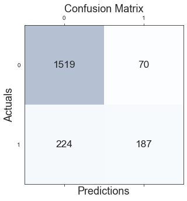

```python
# Display the Confusion Matrix
fig, ax = plt.subplots(figsize=(5, 5))
ax.matshow(cm, cmap=plt.cm.Blues, alpha=0.3)
for i in range(cm.shape[0]):
    for j in range(cm.shape[1]):
        ax.text(x=j, y=i,s=cm[i, j], va='center', ha='center', size='xx-large')
plt.xlabel('Predictions', fontsize=18)
plt.ylabel('Actuals', fontsize=18)
plt.title('Confusion Matrix', fontsize=18)
plt.show()
```

```python
#prediction variable
from sklearn.metrics import accuracy_score
score=accuracy_score(y_pred.astype('int'),y_test.astype('int'))
print('Accuracy = ', score)
```

```
Accuracy =  0.853
```

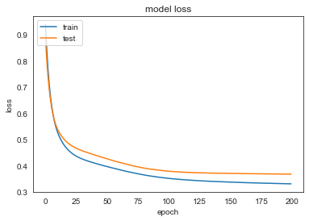

```python
# Plot loss vs value loss
plt.plot(hist['loss'])
plt.plot(hist['val_loss'])
plt.title('model loss')
plt.ylabel('loss')
plt.xlabel('epoch')
plt.legend(['train', 'test'], loc='upper left')
plt.show()
```

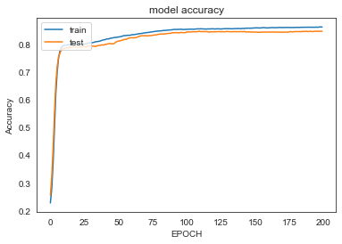

```python
# Plot Accuracy vs Value Accuracy
plt.plot(hist['accuracy'])
plt.plot(hist['val_accuracy'])
plt.title('model accuracy')
plt.ylabel('Accuracy')
plt.xlabel('EPOCH')
plt.legend(['train', 'test'], loc='upper left')
plt.show()
```

### Part A Summary

The model was run with different number of learning rates (.0001,.001. .01, .1), epochs(50, 100, 200,300), hidden layers (1, 2), and nodes (8, 10, 13, 21, 34, 52, 111), activation(relu, tanh, sigmoid), and optimizer (Adam, SGD) . Accuracy ranged from .8415 to .865. My objective was to achieve minimum loss, good accuracy at .9 or higher and good Confusion Matrix results. The sample run listed above has a Loss score of 0.3595 and an Accuracy score of 0.8530. However, the purpose of this model is to identify potential churn customers and determine how to keep them as bank customers. The Confusion Matrix (224 wrong and 187 correct) indicates (recall is only .45 and f1 is .56) that the model is no better than flipping a coin for determining if a customer is likely churn candidate. The data or lack of data for previous churn customers is only 20% of our population. To improve the model, we need to address the data imbalance. This will be shown in Part C. Information that may be valuable to management includes most customers are from France (50%), are male (55%), average credit score is 650 with a range from 850 to 350. Other statistical information is listed above.

```python
# End for Part A - initial model
```